# Community ecology - Computer lab II - AB332

Anders K. Krabberød (UiO) and Ramiro Logares (ICM)

October 2024

# Computer lab II

First load the necessary packages.

Now load the the data from the previous lab (change path to the file if necessary):

```r
load("AB332_lab_I.RData")
```

# Distance metrics

Let’s calculate the Bray Curtis dissimilarities for the rarefied dataset

```r
as.matrix(otu.tab.trans.ss.nozero.bray)[1:5, 1:5]
```

```
           Isa_120223 Isa_120301 Isa_120308 Isa_120320 Isa_120321
Isa_120223  0.0000000  0.3108258  0.2664748  0.2914176  0.2985020
Isa_120301  0.3108258  0.0000000  0.2464763  0.2059627  0.2111283
Isa_120308  0.2664748  0.2464763  0.0000000  0.2574718  0.2862519
Isa_120320  0.2914176  0.2059627  0.2574718  0.0000000  0.1340860
Isa_120321  0.2985020  0.2111283  0.2862519  0.1340860  0.0000000
```

- *What kind of data is the Bray-Curtis dissimilarity suitable for?*
- *How can you change the dissimilarity index in the previous chunk of code?*

# Ordination and clustering

## PCA

Pca from the rarefied table

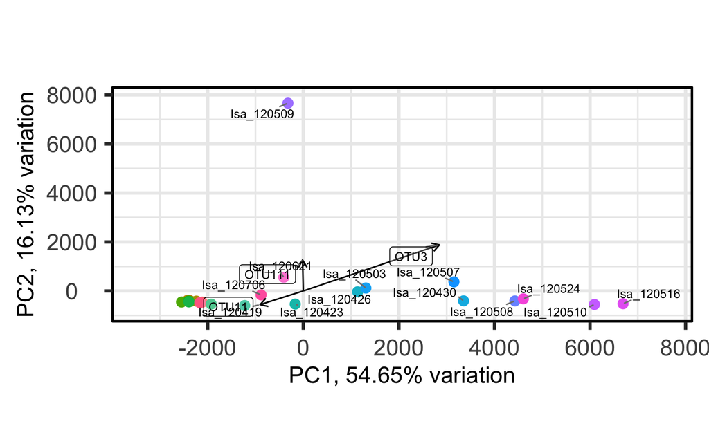

```r
otu.tab.trans.ss.nozero.pca <- PCAtools::pca(t(otu.tab.trans.ss.nozero), scale = FALSE) # Runs the PCA
biplot(otu.tab.trans.ss.nozero.pca, showLoadings = T, lab = rownames(otu.tab.trans.ss.nozero)) # Plots the PCA
```

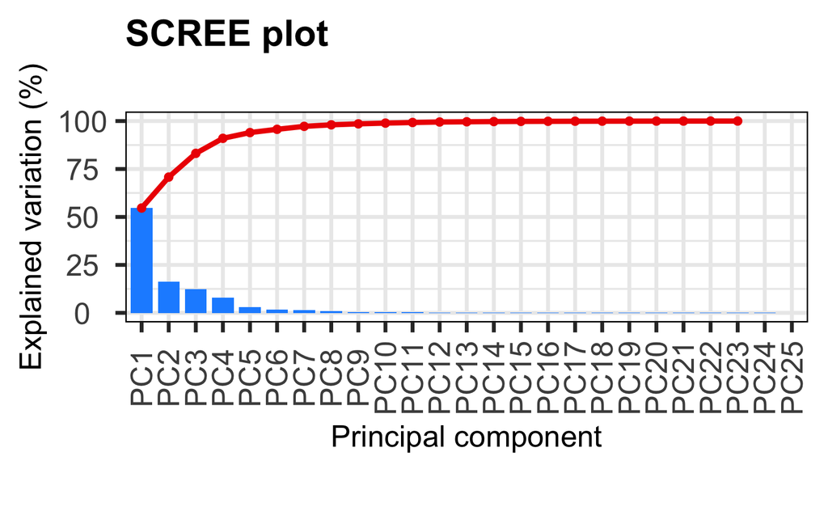

```r
screeplot(otu.tab.trans.ss.nozero.pca, axisLabSize = 18, titleLabSize = 22) # We plot the percentage of variance explained by each axis
```

## NMDS

We will define the function NMDS.scree() that automatically performs a NMDS for 1-7 dimensions and plots the number of dimensions vs. stress

```r
set.seed(666) # Set a seed to make results reproducible
NMDS.scree <- function(x) { # x is the name of the distance matrix
  plot(rep(1, 7), replicate(7, metaMDS(x, autotransform = FALSE, k = 1)$stress), xlim = c(1, 7), ylim = c(0, 0.30), xlab = "# of Dimensions", ylab = "Stress", main = "NMDS stress plot")
  for (i in 1:7) {
    points(rep(i + 1, 7), replicate(7, metaMDS(x, autotransform = FALSE, k = i + 1)$stress))
  }
}
```

We calculate NMDS for k(dimensions)=2 Rarefied table (we use the dataframe to have access to sample and OTU names)

```r
otu.tab.trans.ss.nozero.bray.nmds <- metaMDS(otu.tab.trans.ss.nozero, k = 2, trymax = 100, trace = FALSE, autotransform = FALSE, distance = "bray")
otu.tab.trans.ss.nozero.bray.nmds
```

```
Call:
metaMDS(comm = otu.tab.trans.ss.nozero, distance = "bray", k = 2,      trymax = 100, autotransform = FALSE, trace = FALSE)

global Multidimensional Scaling using monoMDS

Data:     otu.tab.trans.ss.nozero
Distance: bray

Dimensions: 2
Stress:     0.06362196
Stress type 1, weak ties
Best solution was repeated 1 time in 38 tries
The best solution was from try 38 (random start)
Scaling: centring, PC rotation, halfchange scaling
Species: expanded scores based on ‘otu.tab.trans.ss.nozero’
```

# Make stressplot

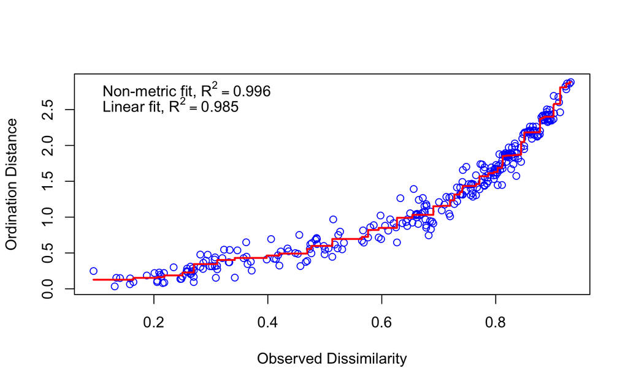

```r
stressplot(otu.tab.trans.ss.nozero.bray.nmds)
```

Simple plotting  
Rarefied table

```r
plot(otu.tab.trans.ss.nozero.bray.nmds, display = "sites", type = "n")
points(otu.tab.trans.ss.nozero.bray.nmds, display = "sites", col = "red", pch = 19)
```

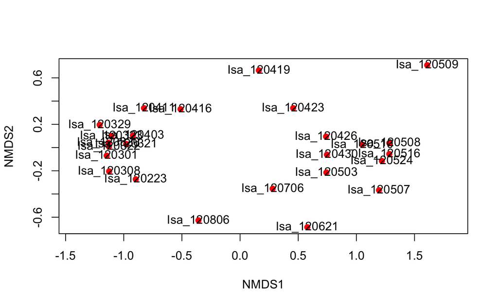

```r
text(otu.tab.trans.ss.nozero.bray.nmds, display = "sites")
```

### Let’s make nicer plots

We get the seasons for samples

|  | date | year | season_nr | seasons | month | day | DOY | running_day | template | depth | declination | daylength | nitrate | phosphate | silicate | N_P | watermass | temp_25 | sal_25 | F_25 | chla_GFF | chla_10 | chl_small | bacteria | virus |
| --- | --- | --- | --- | --- | --- | --- | --- | --- | --- | --- | --- | --- | --- | --- | --- | --- | --- | --- | --- | --- | --- | --- | --- | --- | --- |
| Isa_120223 | 23-Feb-12 | 2012 | 1 | winter | 2 | 23 | 54 | 419 | 1 | 25 | -9.92 | 5 | 6.85 | 0.42 | 3.94 | 16.4 | 5 | -0.3365000 | 34.34000 | 0.00000000 | 0.01501667 | 0.005950000 | 0.009000 | 25569416 | 160216949 |
| Isa_120301 | 01-Mar-12 | 2012 | 2 | spring | 3 | 1 | 61 | 426 | 1 | 25 | -7.66 | 7 | 6.38 | 0.50 | 3.20 | 12.7 | 3 | 1.3284000 | 34.62000 | 0.00000000 | 0.02096667 | 0.010341667 | 0.011000 | 35347574 | 236494102 |
| Isa_120308 | 08-Mar-12 | 2012 | 2 | spring | 3 | 8 | 68 | 433 | 1 | 25 | -4.52 | 9 | 3.98 | 0.33 | 1.95 | 12.2 | NA | 1.1212000 | 34.61750 | 0.00000000 | 0.01501667 | 0.008500000 | 0.007000 | 460490 | 14842982 |
| Isa_120320 | 20-Mar-12 | 2012 | 2 | spring | 3 | 20 | 80 | 445 | 1 | 25 | 0.32 | 12 | 9.39 | 0.66 | 5.50 | 14.3 | 5 | 0.9140000 | 34.61500 | 0.00000000 | 0.01317500 | 0.010058333 | 0.003000 | 3067808 | 122004027 |
| Isa_120321 | 21-Mar-12 | 2012 | 2 | spring | 3 | 21 | 81 | 446 | 1 | 25 | 0.72 | 12 | 4.82 | 0.47 | 2.30 | 10.3 | 2 | 1.3662500 | 34.71000 | 0.00000000 | 0.01671667 | 0.008925000 | 0.008000 | 361644 | 3937919 |
| Isa_120322 | 22-Mar-12 | 2012 | 2 | spring | 3 | 22 | 82 | 447 | 1 | 25 | 1.12 | 13 | 4.26 | 0.39 | 1.90 | 10.8 | 2 | 1.9827500 | 34.77250 | 0.00000000 | 0.02054167 | 0.009491667 | 0.011000 | 293220 | 5671576 |
| Isa_120323 | 23-Mar-12 | 2012 | 2 | spring | 3 | 23 | 83 | 448 | 1 | 25 | 1.52 | 13 | 8.23 | 0.54 | 4.97 | 15.2 | 3 | 1.2695000 | 34.68500 | 0.00000000 | 0.01877083 | 0.010695834 | 0.008075 | 624099 | 18447977 |
| Isa_120329 | 29-Mar-12 | 2012 | 2 | spring | 3 | 29 | 89 | 454 | 1 | 25 | 3.92 | 14 | 7.59 | 0.86 | 3.52 | 8.9 | 2 | 1.9096667 | 34.79000 | 0.00000000 | 0.01700000 | 0.011900000 | 0.005000 | 334140 | 3851871 |
| Isa_120403 | 03-Apr-12 | 2012 | 2 | spring | 4 | 3 | 94 | 459 | 1 | 25 | 5.88 | 16 | 4.87 | 0.54 | 2.35 | 9.0 | 2 | 1.2520000 | 34.73500 | 0.00000000 | 0.04774167 | 0.024791667 | 0.023000 | 328804 | 4615040 |
| Isa_120411 | 11-Apr-12 | 2012 | 2 | spring | 4 | 11 | 102 | 467 | 1 | 25 | 8.91 | 18 | 9.02 | 0.70 | 4.10 | 12.9 | 2 | 1.4846667 | 34.83667 | 0.01500000 | 0.11928333 | 0.060916667 | 0.058000 | 43950699 | 137057832 |

[output cut: 15 more lines]

Rarefied table We generate a table of nmds scores and other features

|  | NMDS1 | NMDS2 | season | month | samples |
| --- | --- | --- | --- | --- | --- |
| Isa_120223 | -0.8967794 | -0.273068223 | winter | 2 | Isa_120223 |
| Isa_120301 | -1.1472648 | -0.069486190 | spring | 3 | Isa_120301 |
| Isa_120308 | -1.1258748 | -0.204645894 | spring | 3 | Isa_120308 |
| Isa_120320 | -1.1321715 | 0.041519487 | spring | 3 | Isa_120320 |
| Isa_120321 | -0.9791818 | 0.030768381 | spring | 3 | Isa_120321 |
| Isa_120322 | -1.1271217 | 0.008084579 | spring | 3 | Isa_120322 |
| Isa_120323 | -1.1068354 | 0.100366014 | spring | 3 | Isa_120323 |
| Isa_120329 | -1.2073653 | 0.195935066 | spring | 3 | Isa_120329 |
| Isa_120403 | -0.9212139 | 0.104558522 | spring | 4 | Isa_120403 |
| Isa_120411 | -0.8262070 | 0.340111310 | spring | 4 | Isa_120411 |

[output cut: 15 more lines]

Create the plot

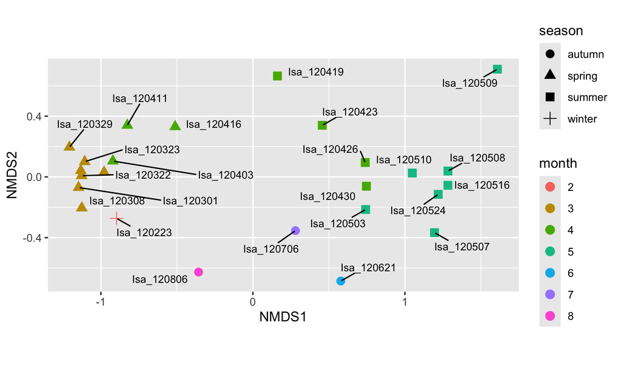

# Clustering of samples

Allows determining the similarity between samples as well as the organization of samples in groups. Hierarchical clustering: samples will be organized in ranks according to their similarity and all samples will be included in a large group Unweighted Pair-Group Method Using Arithmetic Averages (UPGMA): This linkage method will link samples by considering their distance to a subgroup arithmetic average. This is a method widely used in ecology

### UPGMA

Rarefied dataset We generate 100 trees by re-sampling and then, we plot the consensus tree

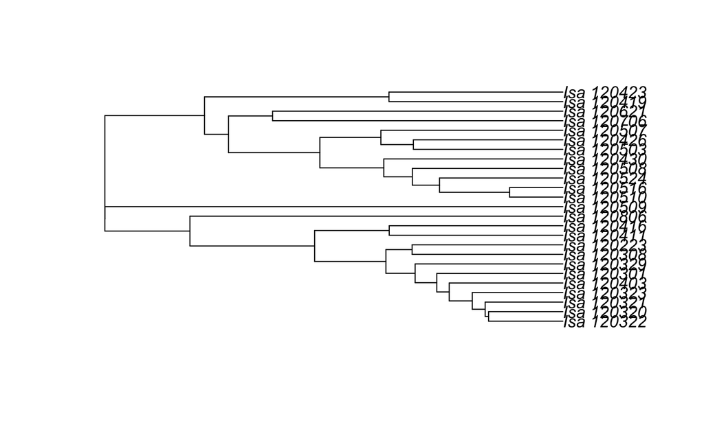

```r
otu.tab.trans.ss.nozero.bray.upgma <- recluster.cons(otu.tab.trans.ss.nozero.bray, tr = 100, p = 0.5, method = "average")
plot(otu.tab.trans.ss.nozero.bray.upgma$cons) # plot consensus tree
```

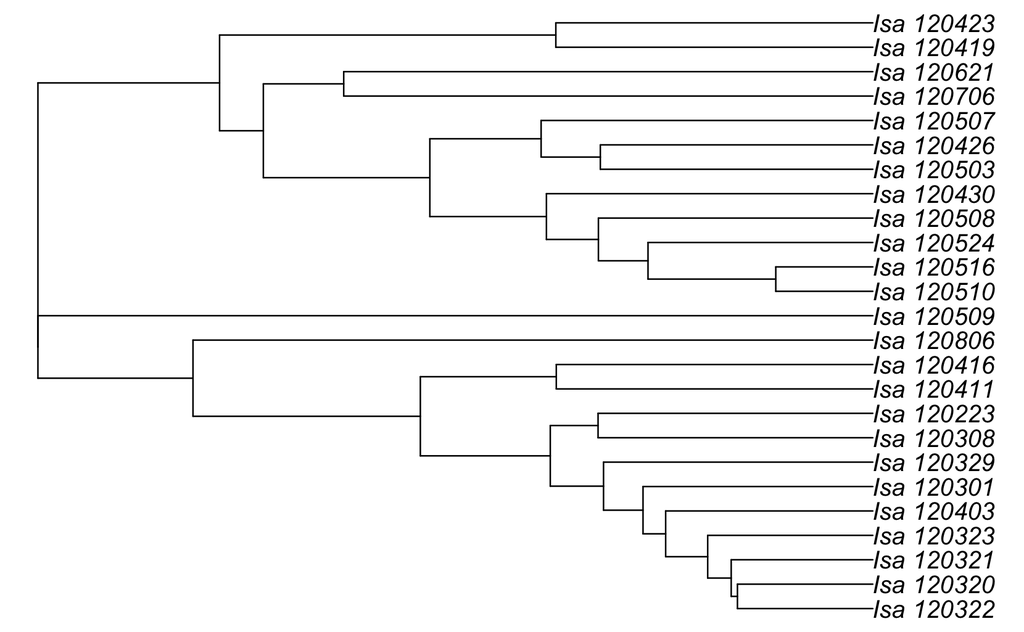

Use Ape to plot

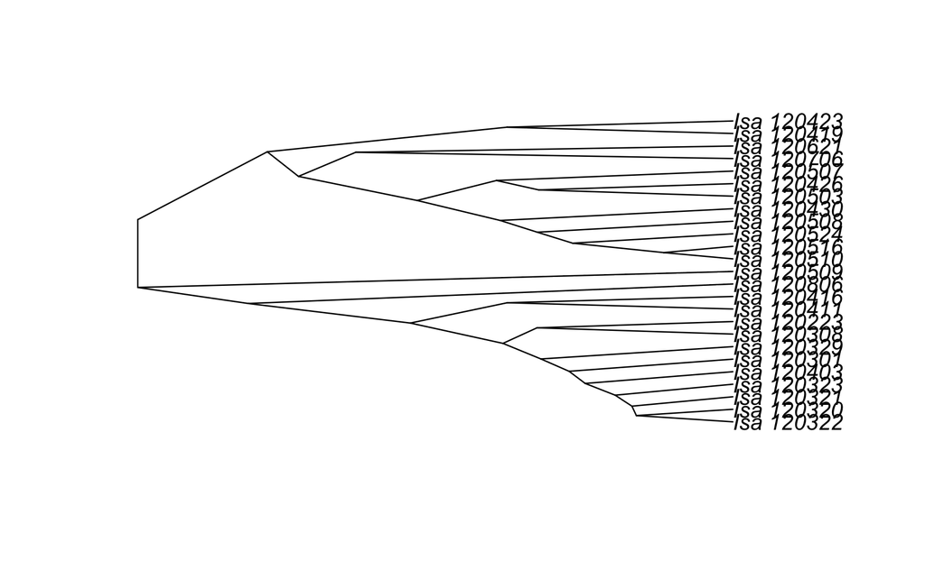

```r
save.image("AB332_lab_II.RData")
```